# Homework 3

Patrick Strzalkowski

29/01/2020

# Part I - ANOVAs

#Killarney Wilderness Park

```r
plank.data=read.csv("Killarney.csv")
plank.data
```

```
##                 Lake    status Diversity
## 1               Acid    Acidic      2.00
## 2        Clearsilver    Acidic      4.65
## 3              David    Acidic      4.09
## 4     deLamorandiere    Acidic      1.11
## 5           Freeland    Acidic      2.06
## 6               Gail    Acidic      1.02
## 7          Killarney    Acidic      2.57
## 8    Little Mountain    Acidic      1.03
## 9    Little Superior    Acidic      1.00
## 10           Lumsden    Acidic      1.75
## 11            Muriel    Acidic      4.40
## 12            Nellie    Acidic      1.04
## 13            Norway    Acidic      1.23
## 14            O.S.A.    Acidic      2.02
```

[output cut: 31 more lines]

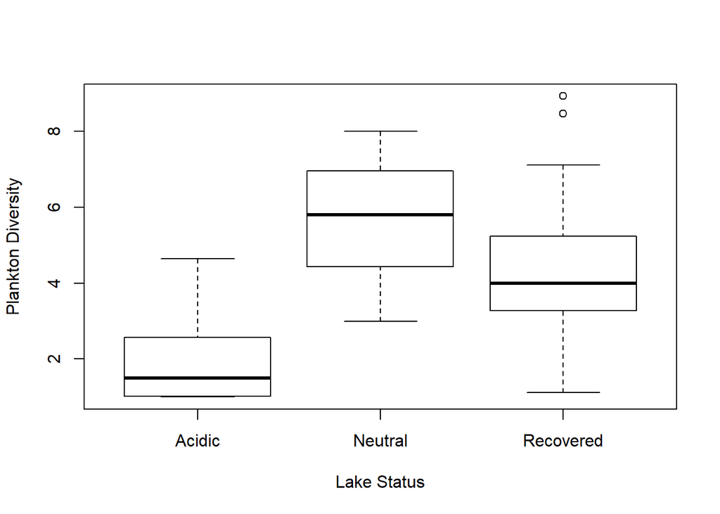

```r
#1
boxplot(plank.data$Diversity~plank.data$status, ylab="Plankton Diversity", xlab="Lake Status")
```

#2 It appears that the Acidic Lakes have a lower diversity of plankton than the Neutral Lakes and probably Recovered Lakes as well

```r
#3: One Factor ANOVA, test for differences of species diversity between the three lake types
plank.fit<-aov(plank.data$Diversity~plank.data$status)
summary(plank.fit)
```

```
##                   Df Sum Sq Mean Sq F value   Pr(>F)
## plank.data$status  2  97.41   48.70   16.41 5.43e-06 ***
## Residuals         42 124.68    2.97
## ---
## Signif. codes:  0 '***' 0.001 '**' 0.01 '*' 0.05 '.' 0.1 ' ' 1
```

#4 The null hypothesis is that the diversity of plankton is independent from the status of the lake. #5 test statistic: F=16.41, p-value=5.43e-06 #6 Since the p-value is less than 0.05 the diversitieis do differ between the three lake types.

```r
#7 - Tukey Test: to determine which lakes differed in their species diversity
TukeyHSD(plank.fit)
```

```
##   Tukey multiple comparisons of means
##     95% family-wise confidence level
##
## Fit: aov(formula = plank.data$Diversity ~ plank.data$status)
##
## $`plank.data$status`
##                        diff       lwr      upr     p adj
## Neutral-Acidic     3.603068  1.874854 5.331282 0.0000253
## Recovered-Acidic   2.418485  1.016843 3.820127 0.0004023
## Recovered-Neutral -1.184583 -3.017179 0.648012 0.2695118
```

#8 Based on the Tukey Test, the Acidic Lakes are signficiantly different than the Recovered and the Neutral Lakes. The Neutral Lakes and the Recovered Lakes are not statistically different from one another.

```r
#9 - Testing for assumptions
#Shapiro Wilks Test for Normality:
shapiro.test(plank.fit$residuals)
```

```
##
##  Shapiro-Wilk normality test
##
## data:  plank.fit$residuals
## W = 0.93501, p-value = 0.01415
```

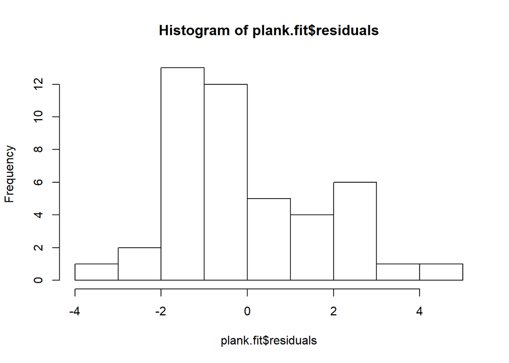

```r
hist(plank.fit$residuals)
```

# Since the p-value < 0.05 we reject the null hypothesis that the residuals are normally distributed, the residuals are not normally distributed.

```r
#Levene's Test that all populations have similar variance:
library("car")
leveneTest(plank.data$Diversity,plank.data$status)
```

```
## Levene's Test for Homogeneity of Variance (center = median)
##       Df F value Pr(>F)
## group  2  0.9977 0.3773
##       42
```

# Since the p-value > 0.05 we fail to reject the null hypothesis that the populations have equal variance. This data meets the assumption that the populations have equal variance

# Esophageal Cancer

```r
#10 - Two factor ANOVA
#a) Tobacco and Alcohol Consumption:
esoph.data<-read.csv("esoph.csv")
esoph.data
```

```
##     X   Age   Alcohol  Tobacco ncases ncontrols
## 1   1 25-34 0-39g/day 0-9g/day      0        40
## 2   2 25-34 0-39g/day    10-19      0        10
## 3   3 25-34 0-39g/day    20-29      0         6
## 4   4 25-34 0-39g/day      30+      0         5
## 5   5 25-34     40-79 0-9g/day      0        27
## 6   6 25-34     40-79    10-19      0         7
## 7   7 25-34     40-79    20-29      0         4
## 8   8 25-34     40-79      30+      0         7
## 9   9 25-34    80-119 0-9g/day      0         2
## 10 10 25-34    80-119    10-19      0         1
## 11 11 25-34    80-119      30+      0         2
## 12 12 25-34      120+ 0-9g/day      0         1
## 13 13 25-34      120+    10-19      1         1
## 14 14 25-34      120+    20-29      0         1
```

[output cut: 74 more lines]

```r
esoph.fit1<-aov(esoph.data$ncases~esoph.data$Alcohol*esoph.data$Tobacco)
summary(esoph.fit1)
```

```
##                                       Df Sum Sq Mean Sq F value Pr(>F)
## esoph.data$Alcohol                     3   46.9  15.624   2.085  0.110
## esoph.data$Tobacco                     3   41.5  13.846   1.848  0.146
## esoph.data$Alcohol:esoph.data$Tobacco  9   31.5   3.501   0.467  0.892
## Residuals                             72  539.5   7.494
```

#b) This ANOVA table does not show a signifcant relationship between alcohol consumption and esophageal cancers cases (p=0.110). It does not show a significant relationship between Tobacco consumption and esophageal cancer either (p=0.146). As well, the interaction between alcohol and tobacco consumption is not significant (p=0.892).

```r
#11a) Tobacco and Age:
esoph.fit2<-aov(esoph.data$ncases~esoph.data$Tobacco*esoph.data$Age)
summary(esoph.fit2)
```

```
##                                   Df Sum Sq Mean Sq F value   Pr(>F)
## esoph.data$Tobacco                 3  41.62   13.87   3.406   0.0228 *
## esoph.data$Age                     5 272.55   54.51  13.384 6.23e-09 ***
## esoph.data$Tobacco:esoph.data$Age 15  84.62    5.64   1.385   0.1822
## Residuals                         64 260.67    4.07
## ---
## Signif. codes:  0 '***' 0.001 '**' 0.01 '*' 0.05 '.' 0.1 ' ' 1
```

```r
#b) Tukey Test
TukeyHSD(esoph.fit2)
```

```
##   Tukey multiple comparisons of means
##     95% family-wise confidence level
##
## Fit: aov(formula = esoph.data$ncases ~ esoph.data$Tobacco * esoph.data$Age)
##
## $`esoph.data$Tobacco`
##                      diff       lwr         upr     p adj
## 10-19-0-9g/day -0.8333333 -2.370109  0.70344196 0.4853668
## 20-29-0-9g/day -1.6000000 -3.211784  0.01178353 0.0524043
## 30+-0-9g/day   -1.7000000 -3.311784 -0.08821647 0.0348451
## 20-29-10-19    -0.7666667 -2.378450  0.84511686 0.5947724
## 30+-10-19      -0.8666667 -2.478450  0.74511686 0.4927118
## 30+-20-29      -0.1000000 -1.783453  1.58345299 0.9986155
##
## $`esoph.data$Age`
##                   diff        lwr        upr     p adj
## 35-44-25-34  0.5266667 -1.6382744  2.6916077 0.9794889
## 45-54-25-34  2.8461111  0.7152658  4.9769564 0.0028395
## 55-64-25-34  4.7211111  2.5902658  6.8519564 0.0000002
## 65-74-25-34  3.5933333  1.4283923  5.7582744 0.0001062
## 75+-25-34    0.8771717 -1.4763673  3.2307107 0.8816351
## 45-54-35-44  2.3194444  0.1885991  4.4502898 0.0251086
## 55-64-35-44  4.1944444  2.0635991  6.3252898 0.0000035
## 65-74-35-44  3.0666667  0.9017256  5.2316077 0.0013005
## 75+-35-44    0.3505051 -2.0030340  2.7040441 0.9978779
## 55-64-45-54  1.8750000 -0.2211951  3.9711951 0.1053407
## 65-74-45-54  0.7472222 -1.3836231  2.8780676 0.9060158
## 75+-45-54   -1.9689394 -4.2911535  0.3532747 0.1422116
## 65-74-55-64 -1.1277778 -3.2586231  1.0030676 0.6306234
## 75+-55-64   -3.8439394 -6.1661535 -1.5217253 0.0001115
## 75+-65-74   -2.7161616 -5.0697006 -0.3626226 0.0145751
##
## $`esoph.data$Tobacco:esoph.data$Age`
##                                        diff          lwr        upr     p adj
## 10-19:25-34-0-9g/day:25-34     2.500000e-01  -5.17250361  5.6725036 1.0000000
## 20-29:25-34-0-9g/day:25-34     1.720846e-15  -5.85697331  5.8569733 1.0000000
## 30+:25-34-0-9g/day:25-34       5.828671e-16  -5.42250361  5.4225036 1.0000000
## 0-9g/day:35-44-0-9g/day:25-34  5.000000e-01  -4.92250361  5.9225036 1.0000000
## 10-19:35-44-0-9g/day:25-34     1.000000e+00  -4.42250361  6.4225036 1.0000000
## 20-29:35-44-0-9g/day:25-34     7.500000e-01  -4.67250361  6.1725036 1.0000000
```

[output cut: 255 more lines]

```
## 30+:65-74-20-29:65-74         -1.833333e+00  -7.69030664  4.0236400 0.9999250
## 0-9g/day:75+-20-29:65-74      -1.000000e+00  -6.42250361  4.4225036 1.0000000
## 10-19:75+-20-29:65-74         -1.250000e+00  -6.67250361  4.1725036 0.9999997
## 20-29:75+-20-29:65-74         -2.500000e+00 -11.07373102  6.0737310 0.9999772
## 30+:75+-20-29:65-74           -1.500000e+00  -8.14118349  5.1411835 0.9999998
## 0-9g/day:75+-30+:65-74         8.333333e-01  -5.02363997  6.6903066 1.0000000
## 10-19:75+-30+:65-74            5.833333e-01  -5.27363997  6.4403066 1.0000000
## 20-29:75+-30+:65-74           -6.666667e-01  -9.52157798  8.1882446 1.0000000
## 30+:75+-30+:65-74              3.333333e-01  -6.66708873  7.3337554 1.0000000
## 10-19:75+-0-9g/day:75+        -2.500000e-01  -5.67250361  5.1725036 1.0000000
## 20-29:75+-0-9g/day:75+        -1.500000e+00 -10.07373102  7.0737310 1.0000000
## 30+:75+-0-9g/day:75+          -5.000000e-01  -7.14118349  6.1411835 1.0000000
## 20-29:75+-10-19:75+           -1.250000e+00  -9.82373102  7.3237310 1.0000000
## 30+:75+-10-19:75+             -2.500000e-01  -6.89118349  6.3911835 1.0000000
## 30+:75+-20-29:75+              1.000000e+00  -8.39205176 10.3920518 1.0000000
```

# c) Based on the ANOVA table, the amount of Tobacco consumed daily (p<0.05) and how old someone is (p<<0.05) has a significant affect on their chance of having esophageal cancer. However, these two variables are not interacting (p=0.1822). The Tukey test displays a significant difference between the frequency of esophageal cancer cases in people that consume 0-9 g of tobacco versus people that consume over 30 g. All other differences are insignificant (p>0.05). The Tukey test displays multiple, significant difference between peoples’ age and their rate of esophageal cancer cases. The frequency is signficantly different between people aged 25-34 vs. 45-54 (p=0.0028), 25-34 vs. 55-64 (p=0.2*10^-6), 25-34 vs. 65-74 (p=0.0001), 35-44 vs. 45-54 (p=0.0251), 35-44 vs. 55-64 (p=0.35*10^-5), 35-44 vs. 65-74 (p=0.0013), 55-64 vs. 75+ (p=0.0001) and 65-74 vs. 75+ (0.0146).

```r
#12a) Alcohol and Age:
esoph.fit3<-aov(esoph.data$ncases~esoph.data$Alcohol*esoph.data$Age)
summary(esoph.fit3)
```

```
##                                   Df Sum Sq Mean Sq F value   Pr(>F)
## esoph.data$Alcohol                 3  46.87   15.62   4.201  0.00892 **
## esoph.data$Age                     5 267.03   53.41  14.361 2.02e-09 ***
## esoph.data$Alcohol:esoph.data$Age 15 107.56    7.17   1.928  0.03633 *
## Residuals                         64 238.00    3.72
## ---
## Signif. codes:  0 '***' 0.001 '**' 0.01 '*' 0.05 '.' 0.1 ' ' 1
```

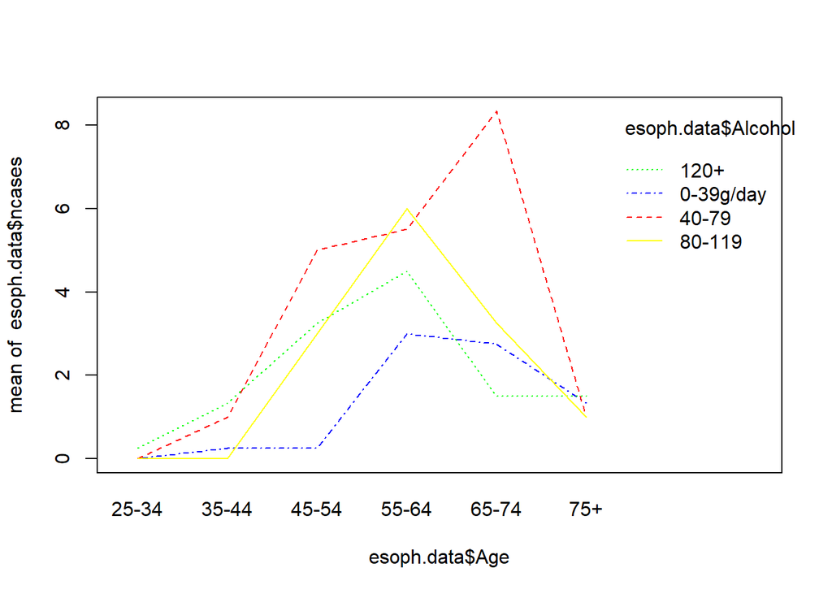

```r
#b) Interaction Plot
interaction.plot(esoph.data$Age,esoph.data$Alcohol,esoph.data$ncases, col=c("blue", "green", "red", "yellow"))
```

# c) The effect of Alcohol and Age on esophageal cases is significant, however their interaction is also significant (p=0.036), therefore we only look at the interaction between the two variables. The interaction plot displays a complicated relationship between alcohol consumption and age. The lines are not parallel, therefore the relationship between alcohol consumption and esophageal cases depends on the person’s age. At young (25-34 y.o.) and old (75+ y.o.) there is little difference, however in the middle ranges of age there are increases of esophageal cases, which also depend on the amount of alcohol consumed.

#Part II - Regression and Correlation

```r
mtcars
```

```
##                      mpg cyl  disp  hp drat    wt  qsec vs am gear carb
## Mazda RX4           21.0   6 160.0 110 3.90 2.620 16.46  0  1    4    4
## Mazda RX4 Wag       21.0   6 160.0 110 3.90 2.875 17.02  0  1    4    4
## Datsun 710          22.8   4 108.0  93 3.85 2.320 18.61  1  1    4    1
## Hornet 4 Drive      21.4   6 258.0 110 3.08 3.215 19.44  1  0    3    1
## Hornet Sportabout   18.7   8 360.0 175 3.15 3.440 17.02  0  0    3    2
## Valiant             18.1   6 225.0 105 2.76 3.460 20.22  1  0    3    1
## Duster 360          14.3   8 360.0 245 3.21 3.570 15.84  0  0    3    4
## Merc 240D           24.4   4 146.7  62 3.69 3.190 20.00  1  0    4    2
## Merc 230            22.8   4 140.8  95 3.92 3.150 22.90  1  0    4    2
## Merc 280            19.2   6 167.6 123 3.92 3.440 18.30  1  0    4    4
## Merc 280C           17.8   6 167.6 123 3.92 3.440 18.90  1  0    4    4
## Merc 450SE          16.4   8 275.8 180 3.07 4.070 17.40  0  0    3    3
## Merc 450SL          17.3   8 275.8 180 3.07 3.730 17.60  0  0    3    3
## Merc 450SLC         15.2   8 275.8 180 3.07 3.780 18.00  0  0    3    3
## Cadillac Fleetwood  10.4   8 472.0 205 2.93 5.250 17.98  0  0    3    4
## Lincoln Continental 10.4   8 460.0 215 3.00 5.424 17.82  0  0    3    4
## Chrysler Imperial   14.7   8 440.0 230 3.23 5.345 17.42  0  0    3    4
## Fiat 128            32.4   4  78.7  66 4.08 2.200 19.47  1  1    4    1
## Honda Civic         30.4   4  75.7  52 4.93 1.615 18.52  1  1    4    2
## Toyota Corolla      33.9   4  71.1  65 4.22 1.835 19.90  1  1    4    1
## Toyota Corona       21.5   4 120.1  97 3.70 2.465 20.01  1  0    3    1
## Dodge Challenger    15.5   8 318.0 150 2.76 3.520 16.87  0  0    3    2
## AMC Javelin         15.2   8 304.0 150 3.15 3.435 17.30  0  0    3    2
## Camaro Z28          13.3   8 350.0 245 3.73 3.840 15.41  0  0    3    4
## Pontiac Firebird    19.2   8 400.0 175 3.08 3.845 17.05  0  0    3    2
## Fiat X1-9           27.3   4  79.0  66 4.08 1.935 18.90  1  1    4    1
## Porsche 914-2       26.0   4 120.3  91 4.43 2.140 16.70  0  1    5    2
## Lotus Europa        30.4   4  95.1 113 3.77 1.513 16.90  1  1    5    2
## Ford Pantera L      15.8   8 351.0 264 4.22 3.170 14.50  0  1    5    4
## Ferrari Dino        19.7   6 145.0 175 3.62 2.770 15.50  0  1    5    6
## Maserati Bora       15.0   8 301.0 335 3.54 3.570 14.60  0  1    5    8
## Volvo 142E          21.4   4 121.0 109 4.11 2.780 18.60  1  1    4    2
```